# STAT 413/613 HW 1

Jiarong Li

2020-09-01

# 1 Canvas Picture, Syllabus, and Student Info

Review the Syllabus on Canvas and answer the following questions:

I, *Jiarong Li* have:

1. Added a photo of myself (headshot) to my Canvas profile
2. Reviewed the syllabus and the associated policies on the following date: Aug 29, 2020
3. Reviewed the American University policies on academic integrity, and understand how they apply to this course and agree to comply with them for this course
4. Filled in my information in the Student Info spreadsheet on Canvas collaborations

# 2 College Scorecard

The data folder contains “college_score_200601.csv”, a subset of the data in the [College Scorecard](https://collegescorecard.ed.gov/data/) database as of June 1, 2020. These data contain information on colleges in the United States. The variables include:

- `UNITID` and `OPEID`: Identifiers for the colleges.
- `INSTNM`: Institution name
- `ADM_RATE`: The Admission Rate.
- `SAT_AVE`: Average SAT equivalent score of students admitted.
- `UGDS`: Enrollment of undergraduate certificate/degree-seeking students
- `COSTT4_A`: Average cost of attendance (academic year institutions)
- `AVGFACSAL`: Average faculty salary
- `GRAD_DEBT_MDN`: The median debt for students who have completed
- `AGE_ENTRY`: Average age of entry
- `ICLEVEL`: Level of institution (1 = 4-year, 2 = 2-year, 3 = less than 2-year).
- `MN_EARN_WNE_P10`: Mean earnings of students working and not enrolled 10 years after entry.
- `MD_EARN_WNE_P10`: Median earnings of students working and not enrolled 10 years after entry.
- `FEMALE`: Share of female students
- `PCT_WHITE`: Percent of the population from students’ zip codes that is White, via Census data
1. Use a relative path and a readr function to load the data from data/college_score_200601.csv into a tibble.

```r
library(tibble)
```

```r
library(ggplot2)
library(ggthemes)
library(tidyverse)
college <- read.csv("~/Documents/Master/Semester-3/STAT-613/hw-01-jiarong0829/data/college_score_200601.csv", header = T)
head(college)
```

```
##   UNITID   OPEID MN_EARN_WNE_P10 MD_EARN_WNE_P10
## 1 100654  100200           35500           31000
## 2 100663  105200           48400           41200
## 3 100690 2503400           47600           39600
## 4 100706  105500           52000           46700
## 5 100724  100500           30600           27700
## 6 100751  105100           51600           44500
##                                INSTNM STABBR SAT_AVG ADM_RATE  UGDS
## 1            Alabama A & M University     AL     957   0.8986  4990
## 2 University of Alabama at Birmingham     AL    1220   0.9211 13186
## 3                  Amridge University     AL    NULL     NULL   351
## 4 University of Alabama in Huntsville     AL    1314   0.8087  7458
## 5            Alabama State University     AL     972   0.9774  3903
## 6           The University of Alabama     AL    1252   0.5906 32177
##   COSTT4_A AVGFACSAL GRAD_DEBT_MDN   AGE_ENTRY      FEMALE   PCT_WHITE
## 1    22489      7101         34500 20.28374137 0.564030132 46.84000015
## 2    24347     10717         22500 23.60797466  0.63909074 69.01999664
## 3    17680      4292         25002  33.6722973 0.648648649 70.87999725
## 4    23441      9442         22021 22.72791963 0.476349937 76.37999725
## 5    21476      7754         32637 20.13099042  0.61341853 42.68999863
## 6    29424     10225         23250  21.1377014 0.615252417 75.34999847
##   ICLEVEL
## 1       1
## 2       1
## 3       1
## 4       1
## 5       1
## 6       1
```

2. If you used the default settings for reading in the data, 11 variables are probably type character when they should be numeric.
- Which ones?
- Why were they read in as type character?

They are: MN_EARN_WNE_P10, MD_EARN_WNE_P10, SAT_AVE, ADM_RATE, UGDS, COSTT4_A, GRAD_DEBT_MDN, AGE_ENTRY, FEMALE, PCT_WHITE, ICLEVEL. Because they have text like NULL or PrivacySuppressed in their column.

3. Fix these variables to be numeric in the tibble.

```r
college <- read.csv("~/Documents/Master/Semester-3/STAT-613/hw-01-jiarong0829/data/college_score_200601.csv", header = T, na.strings = c("NULL", "PrivacySuppressed"))
head(college)
```

```
##   UNITID   OPEID MN_EARN_WNE_P10 MD_EARN_WNE_P10
## 1 100654  100200           35500           31000
## 2 100663  105200           48400           41200
## 3 100690 2503400           47600           39600
## 4 100706  105500           52000           46700
## 5 100724  100500           30600           27700
## 6 100751  105100           51600           44500
##                                INSTNM STABBR SAT_AVG ADM_RATE  UGDS
## 1            Alabama A & M University     AL     957   0.8986  4990
## 2 University of Alabama at Birmingham     AL    1220   0.9211 13186
## 3                  Amridge University     AL      NA       NA   351
## 4 University of Alabama in Huntsville     AL    1314   0.8087  7458
## 5            Alabama State University     AL     972   0.9774  3903
## 6           The University of Alabama     AL    1252   0.5906 32177
##   COSTT4_A AVGFACSAL GRAD_DEBT_MDN AGE_ENTRY    FEMALE PCT_WHITE ICLEVEL
## 1    22489      7101         34500  20.28374 0.5640301     46.84       1
## 2    24347     10717         22500  23.60797 0.6390907     69.02       1
## 3    17680      4292         25002  33.67230 0.6486486     70.88       1
## 4    23441      9442         22021  22.72792 0.4763499     76.38       1
## 5    21476      7754         32637  20.13099 0.6134185     42.69       1
## 6    29424     10225         23250  21.13770 0.6152524     75.35       1
```

4. How is average faculty salary associated the median earnings of students ten years after initial enrollment? Create an appropriate plot and interpret the plot to justify your answer.

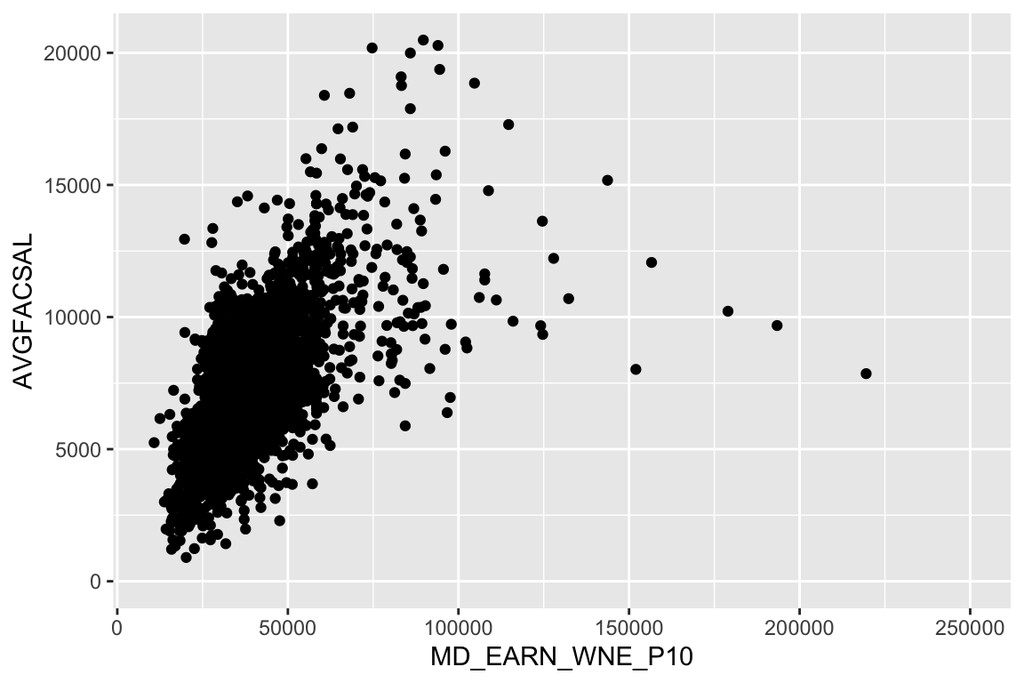

```r
ggplot(data = college)+
  geom_point(mapping = aes(x = MD_EARN_WNE_P10, y = AVGFACSAL))
```

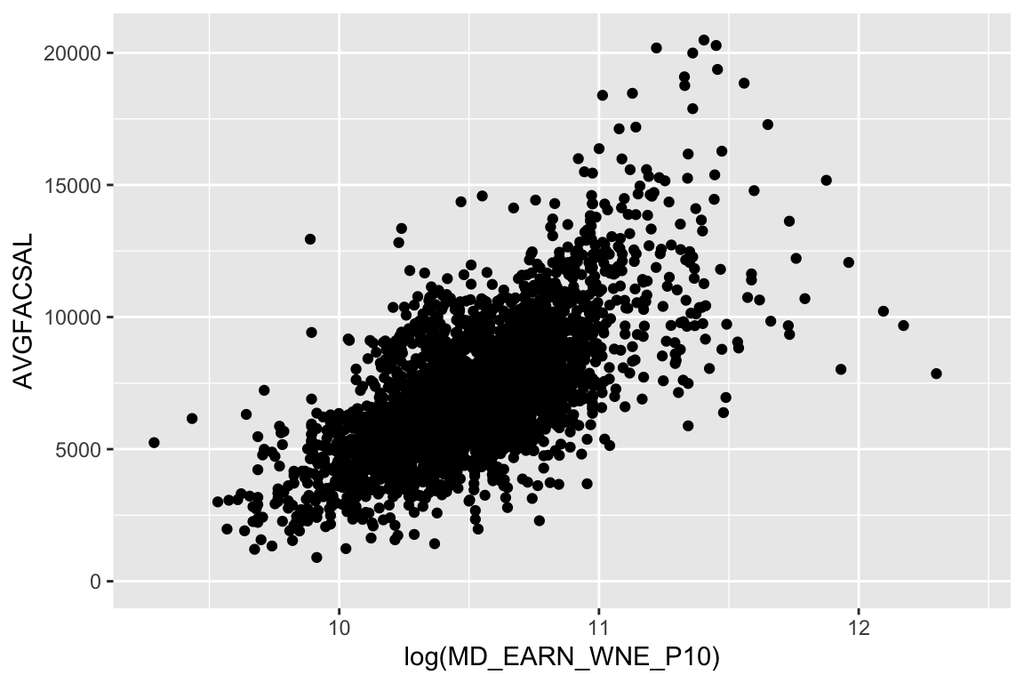

```r
ggplot(data = college)+
  geom_point(mapping = aes(x = log(MD_EARN_WNE_P10), y = AVGFACSAL))
```

```r
# From the plot below we can see that there is a positive relationship between meidan earnings of student working and not enrolled 10 years after entry and average faculty salary. Most of the median salary is below $50,000. After we log the median salary, this relationship is more stronger and easier to see.
```

5. Does the level of the institution seem to be associated with the median earnings of students ten years after enrollment? Reproduce this plot in R to explore this relationship and interpret the plot:

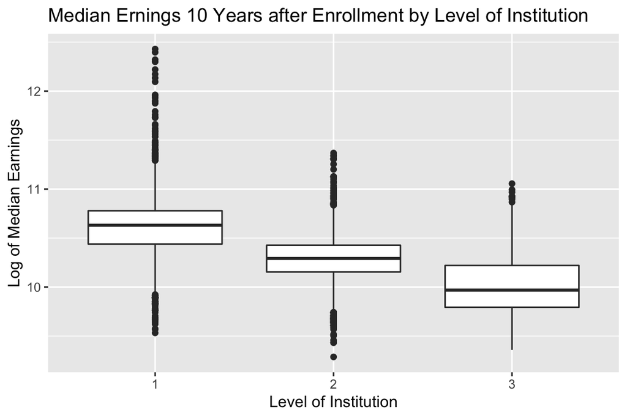

```r
ggplot(data = college)+
  geom_boxplot(mapping = aes(x = as.factor(ICLEVEL), y = log(MD_EARN_WNE_P10)))+
  labs(x = "Level of Institution", y = "Log of Median Earnings", title = "Median Ernings 10 Years after Enrollment by Level of Institution")
```

```r
# Yes, it seems to jave association between the level of the institution and the median earnings of students ten years after enrollment. From the boxplot we can see that with the level of institution increase, the median earning is decreasing. In other words, if a person have more years attend to school, he/she will earn more 10 years after enrollment.
```

6. Plot the log of median earnings 10 years after enrollment for level 1 institutions as the Y axis against PCT_WHITE and, in a second plot, against FEMALE.
- Describe the relationship if any in each of the plots.

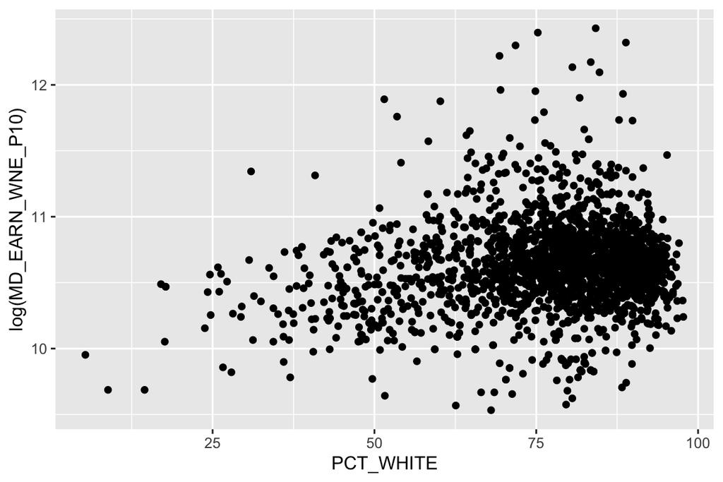

```r
college1 <- college %>%
  filter(ICLEVEL == 1)
ggplot(data = college1)+
  geom_point(mapping = aes(x = PCT_WHITE, y = log(MD_EARN_WNE_P10)))
```

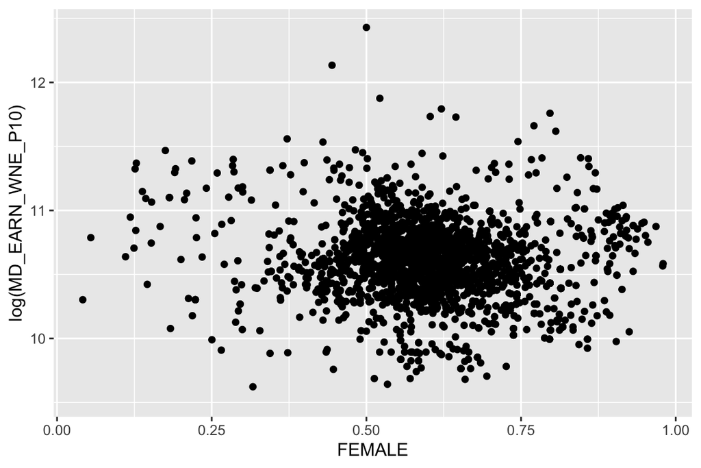

```r
ggplot(data = college1)+
  geom_point(mapping = aes(x = FEMALE, y = log(MD_EARN_WNE_P10)))
```